# examples_0602

The figure below shows 7 polygons on a $10\times10$ grid. The grid is composed of 100 squares, each with an area of 1. Each polygon's area is labelled with an uppercase letter from $A$ to $G$.

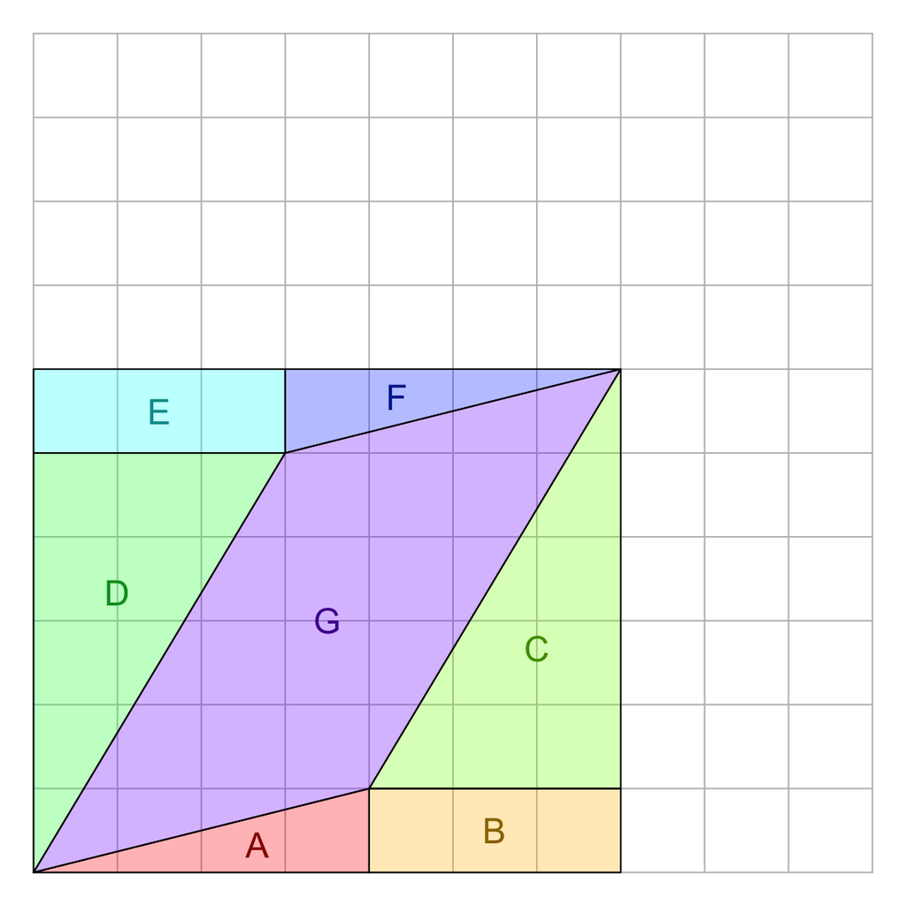

Find the areas of the triangles, rectangles, and parallelogram.

- $A=$
- $B=$
- $C=$
- $D=$
- $E=$
- $F=$
- $G=$
- Remember the area of a rectangle is width times height.
- Remember the area of a triangle is half of base times height.
  - For a right triangle, half the product of the legs.
- To find the area of the parallelogram, you can subtract all 6 other areas from the total area of the rectangle containing all 7 pieces.
- $a=2$
- $b=3$
- $c=7.5$
- $d=7.5$
- $e=3$
- $f=2$
- $g=17$

The figure below shows 7 polygons on a $10\times10$ grid. The grid is composed of 100 squares, each with an area of 1. Each polygon's area is labelled with an uppercase letter from $A$ to $G$.

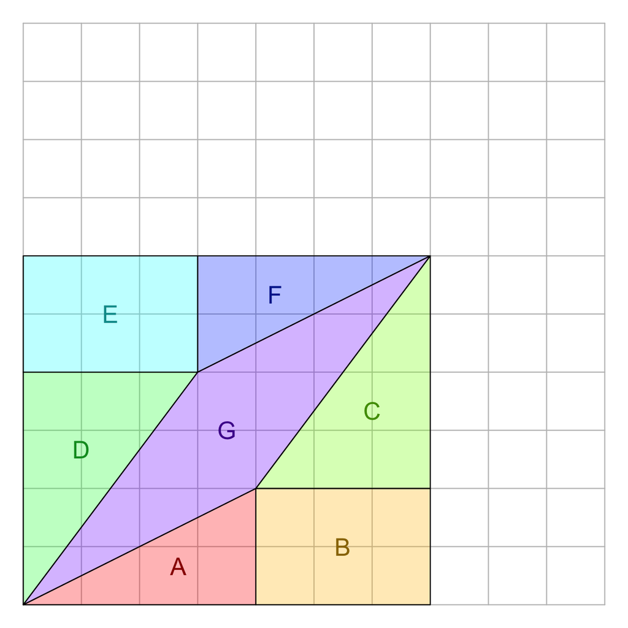

Find the areas of the triangles, rectangles, and parallelogram.

- $A=$
- $B=$
- $C=$
- $D=$
- $E=$
- $F=$
- $G=$
- Remember the area of a rectangle is width times height.
- Remember the area of a triangle is half of base times height.
  - For a right triangle, half the product of the legs.
- To find the area of the parallelogram, you can subtract all 6 other areas from the total area of the rectangle containing all 7 pieces.
- $a=4$
- $b=6$
- $c=6$
- $d=6$
- $e=6$
- $f=4$
- $g=10$

The figure below shows 7 polygons on a $10\times10$ grid. The grid is composed of 100 squares, each with an area of 1. Each polygon's area is labelled with an uppercase letter from $A$ to $G$.

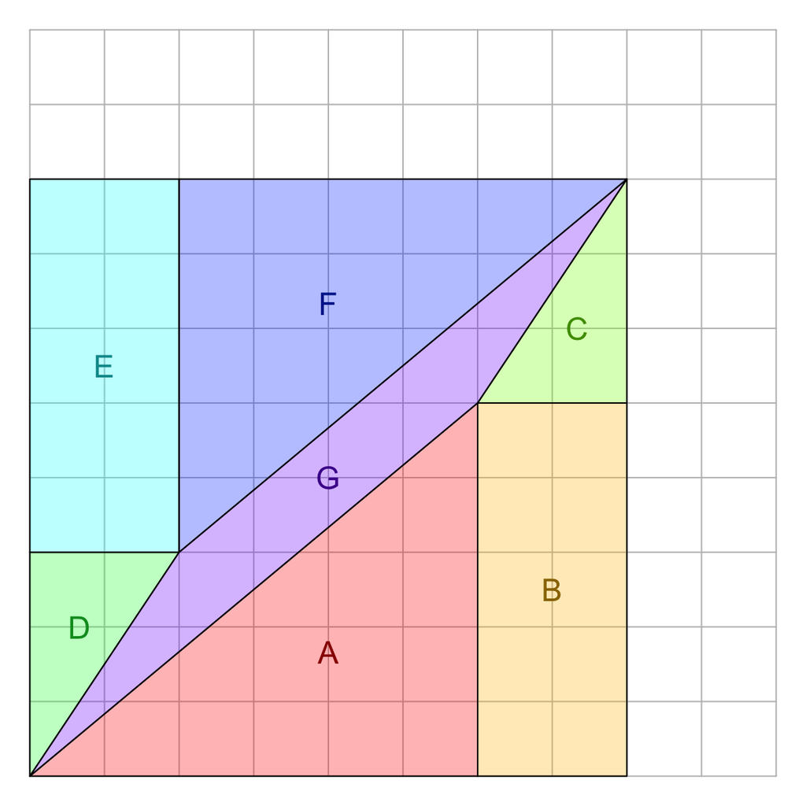

Find the areas of the triangles, rectangles, and parallelogram.

- $A=$
- $B=$
- $C=$
- $D=$
- $E=$
- $F=$
- $G=$
- Remember the area of a rectangle is width times height.
- Remember the area of a triangle is half of base times height.
  - For a right triangle, half the product of the legs.
- To find the area of the parallelogram, you can subtract all 6 other areas from the total area of the rectangle containing all 7 pieces.
- $a=15$
- $b=10$
- $c=3$
- $d=3$
- $e=10$
- $f=15$
- $g=8$

The figure below shows 7 polygons on a $10\times10$ grid. The grid is composed of 100 squares, each with an area of 1. Each polygon's area is labelled with an uppercase letter from $A$ to $G$.

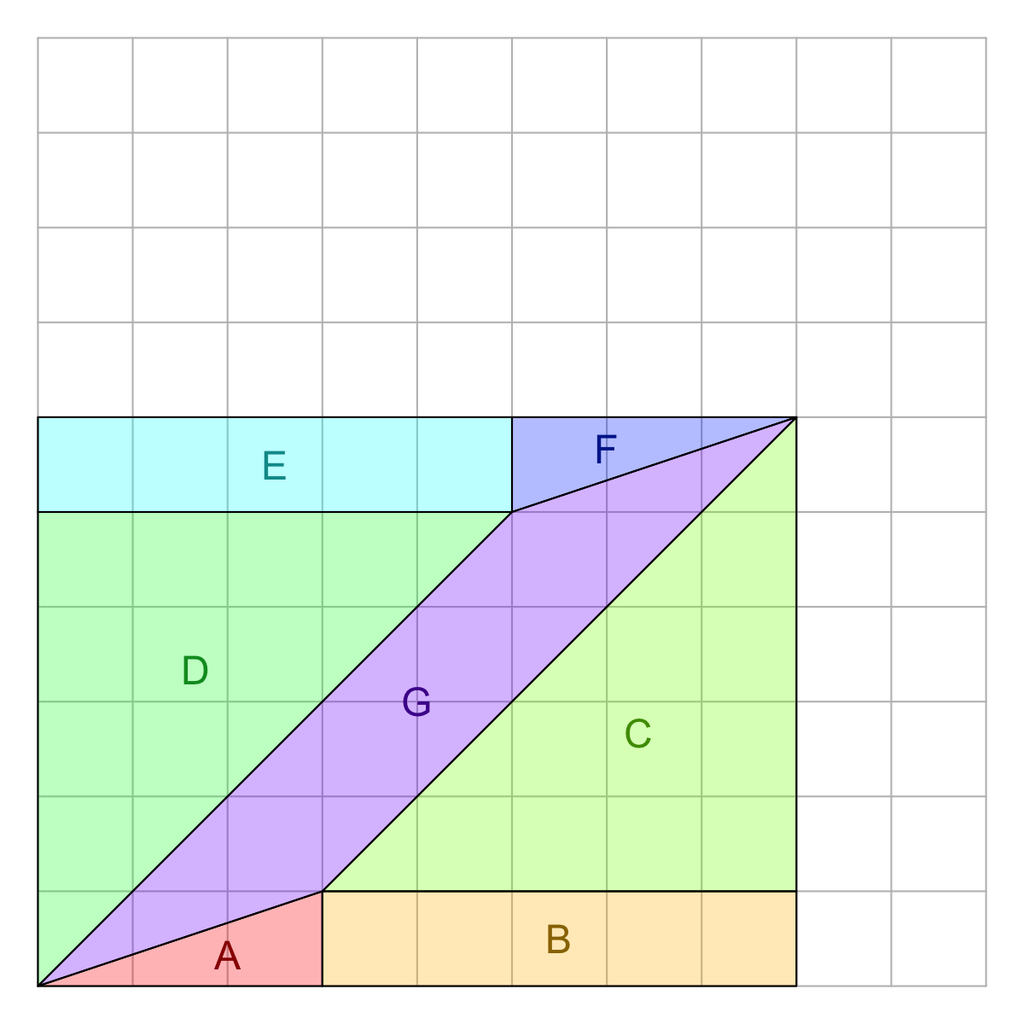

Find the areas of the triangles, rectangles, and parallelogram.

- $A=$
- $B=$
- $C=$
- $D=$
- $E=$
- $F=$
- $G=$
- Remember the area of a rectangle is width times height.
- Remember the area of a triangle is half of base times height.
  - For a right triangle, half the product of the legs.
- To find the area of the parallelogram, you can subtract all 6 other areas from the total area of the rectangle containing all 7 pieces.
- $a=1.5$
- $b=5$
- $c=12.5$
- $d=12.5$
- $e=5$
- $f=1.5$
- $g=10$

The figure below shows 7 polygons on a $10\times10$ grid. The grid is composed of 100 squares, each with an area of 1. Each polygon's area is labelled with an uppercase letter from $A$ to $G$.

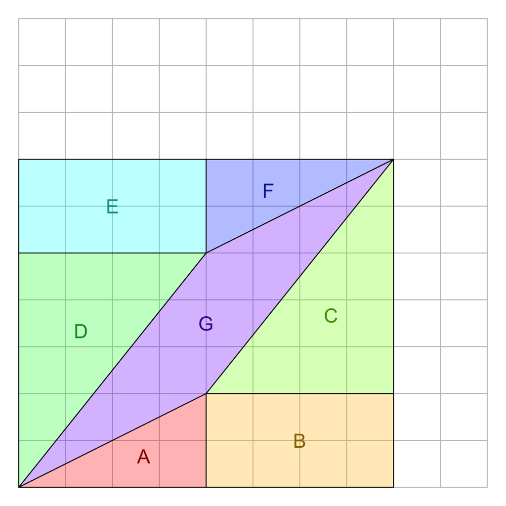

Find the areas of the triangles, rectangles, and parallelogram.

- $A=$
- $B=$
- $C=$
- $D=$
- $E=$
- $F=$
- $G=$
- Remember the area of a rectangle is width times height.
- Remember the area of a triangle is half of base times height.
  - For a right triangle, half the product of the legs.
- To find the area of the parallelogram, you can subtract all 6 other areas from the total area of the rectangle containing all 7 pieces.
- $a=4$
- $b=8$
- $c=10$
- $d=10$
- $e=8$
- $f=4$
- $g=12$

The figure below shows 7 polygons on a $10\times10$ grid. The grid is composed of 100 squares, each with an area of 1. Each polygon's area is labelled with an uppercase letter from $A$ to $G$.

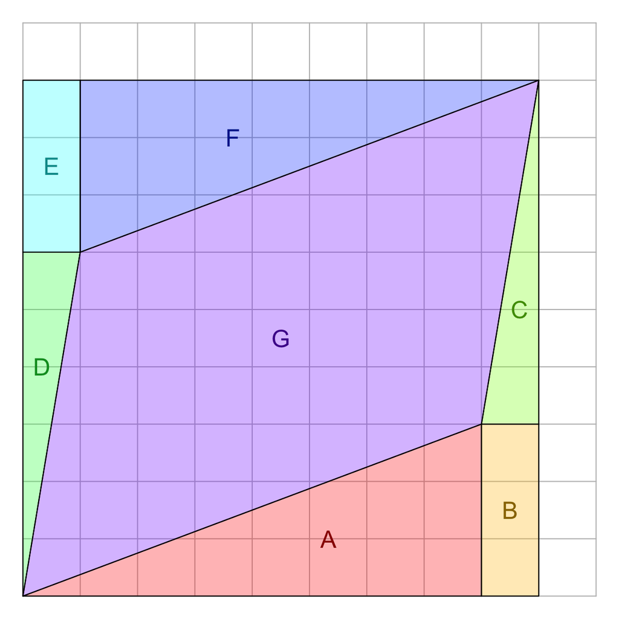

Find the areas of the triangles, rectangles, and parallelogram.

- $A=$
- $B=$
- $C=$
- $D=$
- $E=$
- $F=$
- $G=$
- Remember the area of a rectangle is width times height.
- Remember the area of a triangle is half of base times height.
  - For a right triangle, half the product of the legs.
- To find the area of the parallelogram, you can subtract all 6 other areas from the total area of the rectangle containing all 7 pieces.
- $a=12$
- $b=3$
- $c=3$
- $d=3$
- $e=3$
- $f=12$
- $g=45$

The figure below shows 7 polygons on a $10\times10$ grid. The grid is composed of 100 squares, each with an area of 1. Each polygon's area is labelled with an uppercase letter from $A$ to $G$.

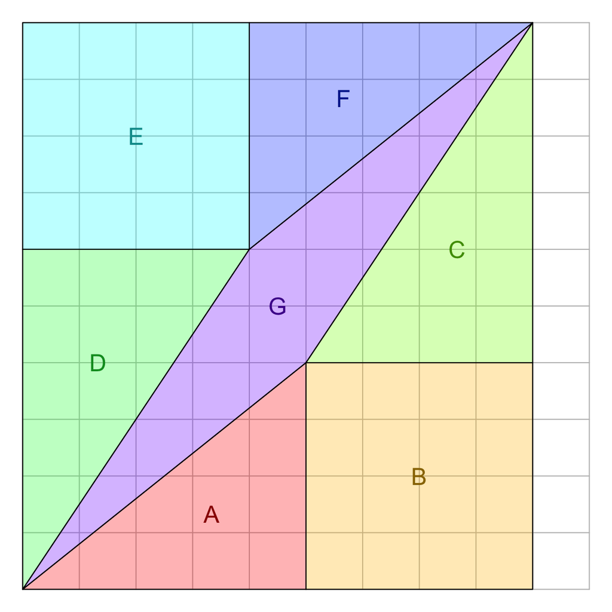

Find the areas of the triangles, rectangles, and parallelogram.

- $A=$
- $B=$
- $C=$
- $D=$
- $E=$
- $F=$
- $G=$
- Remember the area of a rectangle is width times height.
- Remember the area of a triangle is half of base times height.
  - For a right triangle, half the product of the legs.
- To find the area of the parallelogram, you can subtract all 6 other areas from the total area of the rectangle containing all 7 pieces.
- $a=10$
- $b=16$
- $c=12$
- $d=12$
- $e=16$
- $f=10$
- $g=14$

The figure below shows 7 polygons on a $10\times10$ grid. The grid is composed of 100 squares, each with an area of 1. Each polygon's area is labelled with an uppercase letter from $A$ to $G$.

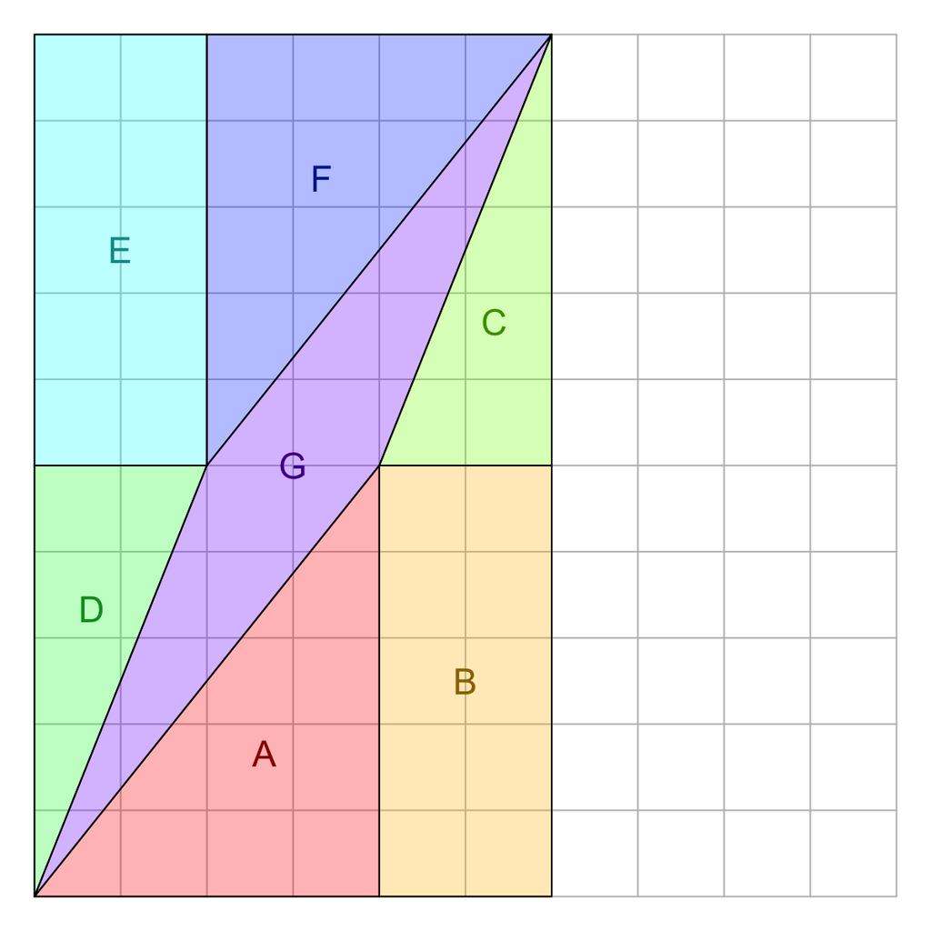

Find the areas of the triangles, rectangles, and parallelogram.

- $A=$
- $B=$
- $C=$
- $D=$
- $E=$
- $F=$
- $G=$
- Remember the area of a rectangle is width times height.
- Remember the area of a triangle is half of base times height.
  - For a right triangle, half the product of the legs.
- To find the area of the parallelogram, you can subtract all 6 other areas from the total area of the rectangle containing all 7 pieces.
- $a=10$
- $b=10$
- $c=5$
- $d=5$
- $e=10$
- $f=10$
- $g=10$

There is actually a shortcut to finding the area of a parallelogram like the one shown below.

$$A=|x_1y_2-x_2y_1|$$

With that in mind, find the area of the parallelogram shown below, where each small grey square has an area of 1.

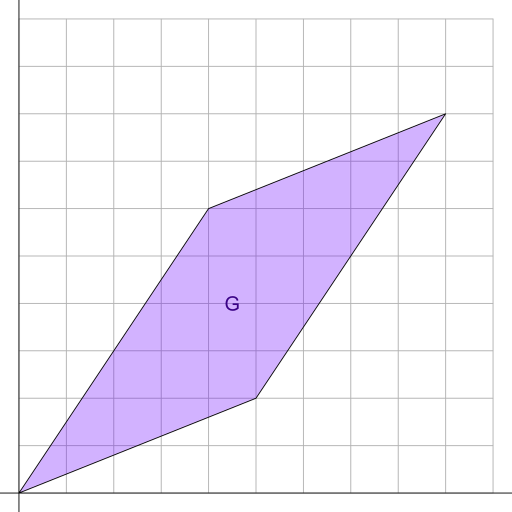

$$G=~?$$

Identify the coordinates of the vertices.

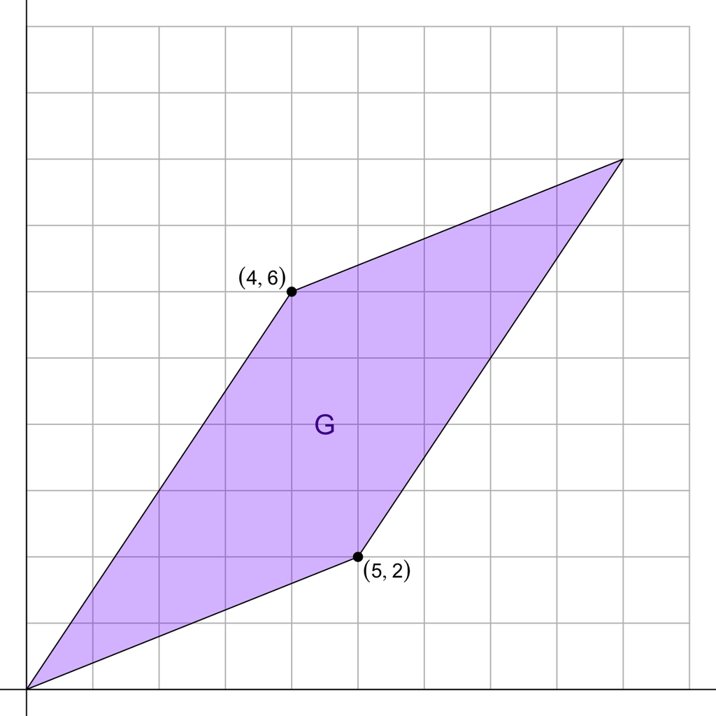

- $x_1 = 5$
- $y_1 = 2$
- $x_2 = 4$
- $y_2 = 6$

Use the formula.

$$G=|5\cdot6-4\cdot2|$$
$$G=22$$

There is actually a shortcut to finding the area of a parallelogram like the one shown below.

$$A=|x_1y_2-x_2y_1|$$

With that in mind, find the area of the parallelogram shown below, where each small grey square has an area of 1.

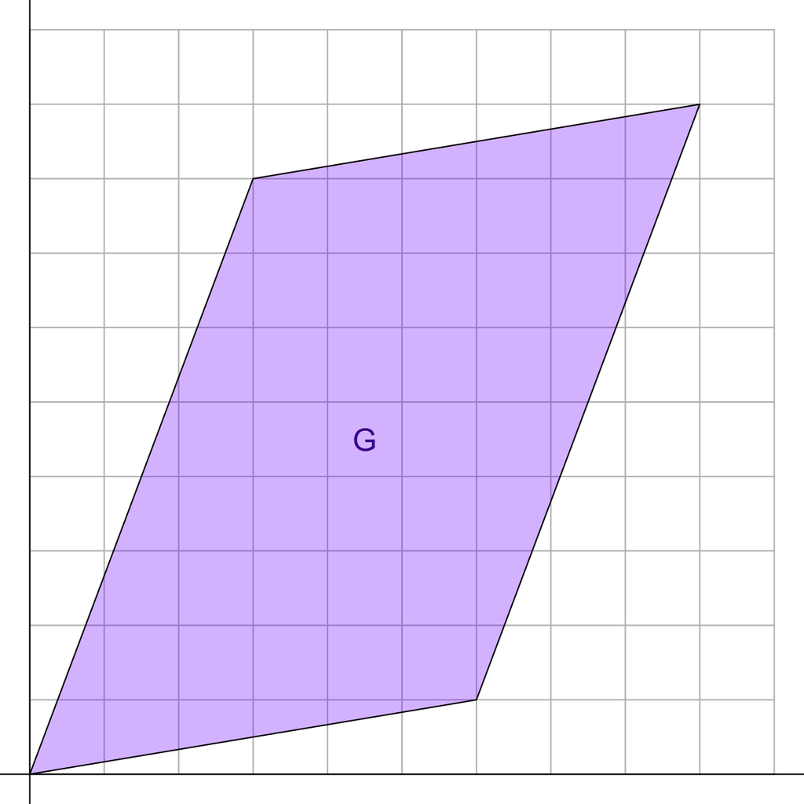

$$G=~?$$

Identify the coordinates of the vertices.

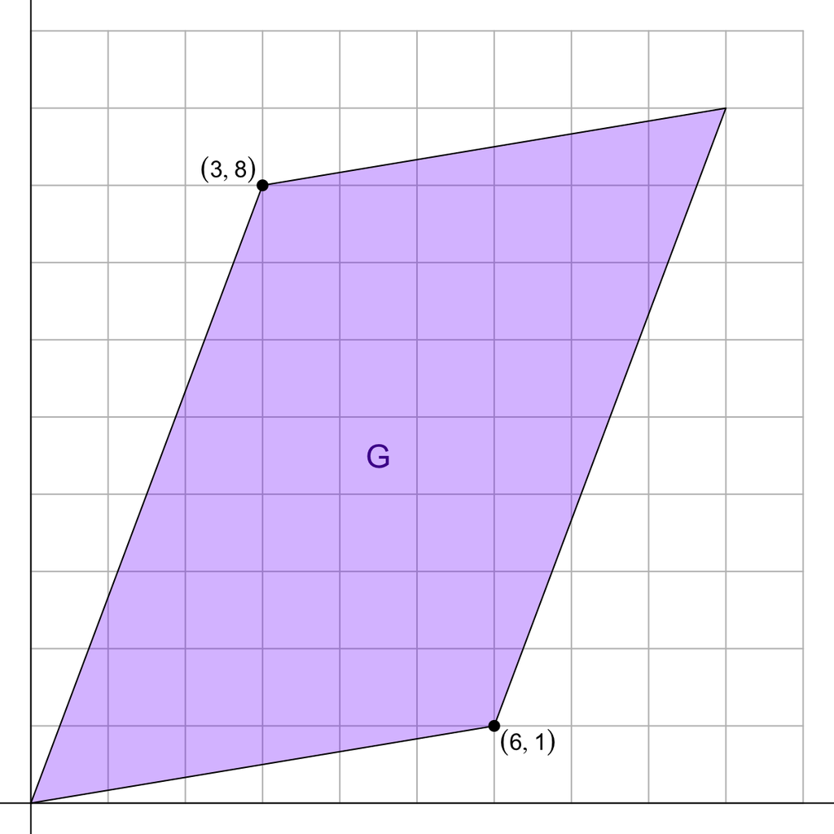

- $x_1 = 6$
- $y_1 = 1$
- $x_2 = 3$
- $y_2 = 8$

Use the formula.

$$G=|6\cdot8-3\cdot1|$$
$$G=45$$

There is actually a shortcut to finding the area of a parallelogram like the one shown below.

$$A=|x_1y_2-x_2y_1|$$

With that in mind, find the area of the parallelogram shown below, where each small grey square has an area of 1.

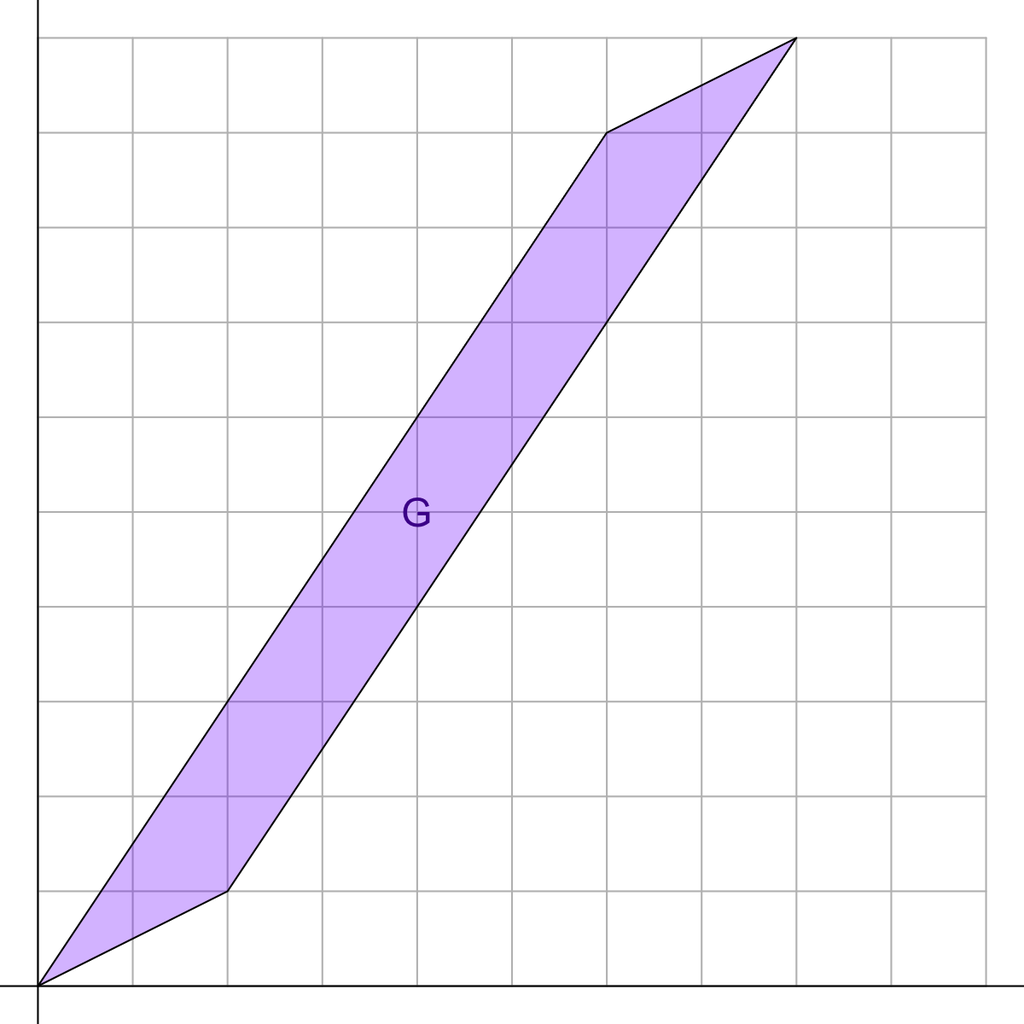

$$G=~?$$

Identify the coordinates of the vertices.

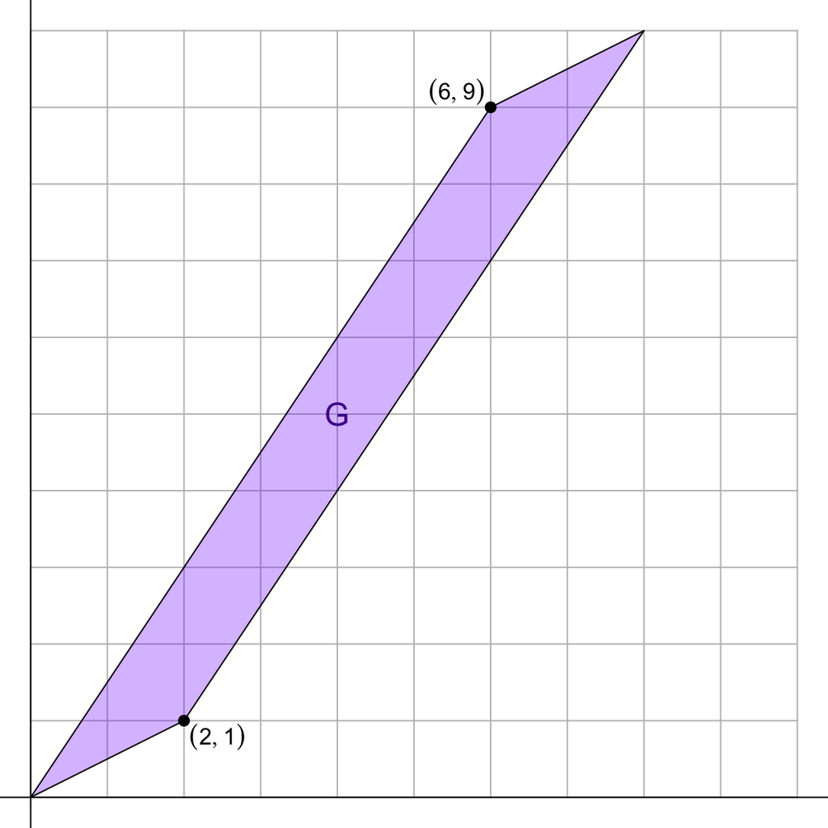

- $x_1 = 2$
- $y_1 = 1$
- $x_2 = 6$
- $y_2 = 9$

Use the formula.

$$G=|2\cdot9-6\cdot1|$$
$$G=12$$

There is actually a shortcut to finding the area of a parallelogram like the one shown below.

$$A=|x_1y_2-x_2y_1|$$

With that in mind, find the area of the parallelogram shown below, where each small grey square has an area of 1.

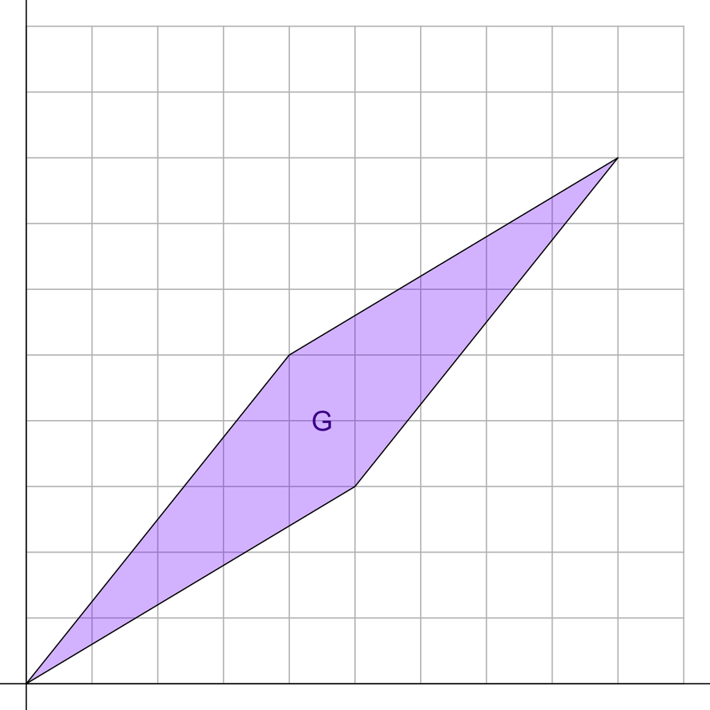

$$G=~?$$

Identify the coordinates of the vertices.

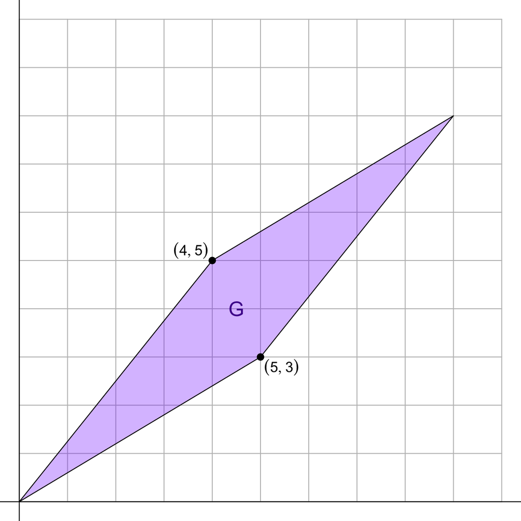

- $x_1 = 5$
- $y_1 = 3$
- $x_2 = 4$
- $y_2 = 5$

Use the formula.

$$G=|5\cdot5-4\cdot3|$$
$$G=13$$

There is actually a shortcut to finding the area of a parallelogram like the one shown below.

$$A=|x_1y_2-x_2y_1|$$

With that in mind, find the area of the parallelogram shown below, where each small grey square has an area of 1.

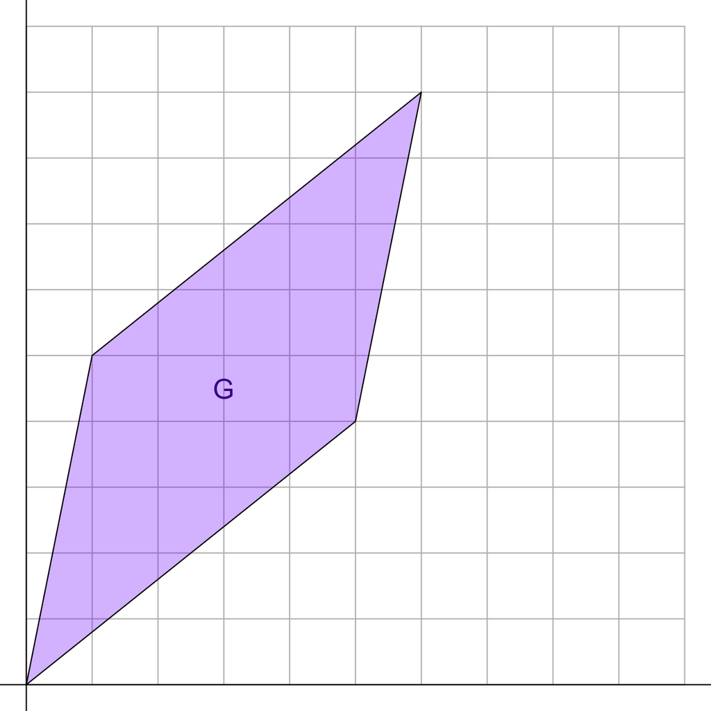

$$G=~?$$

Identify the coordinates of the vertices.

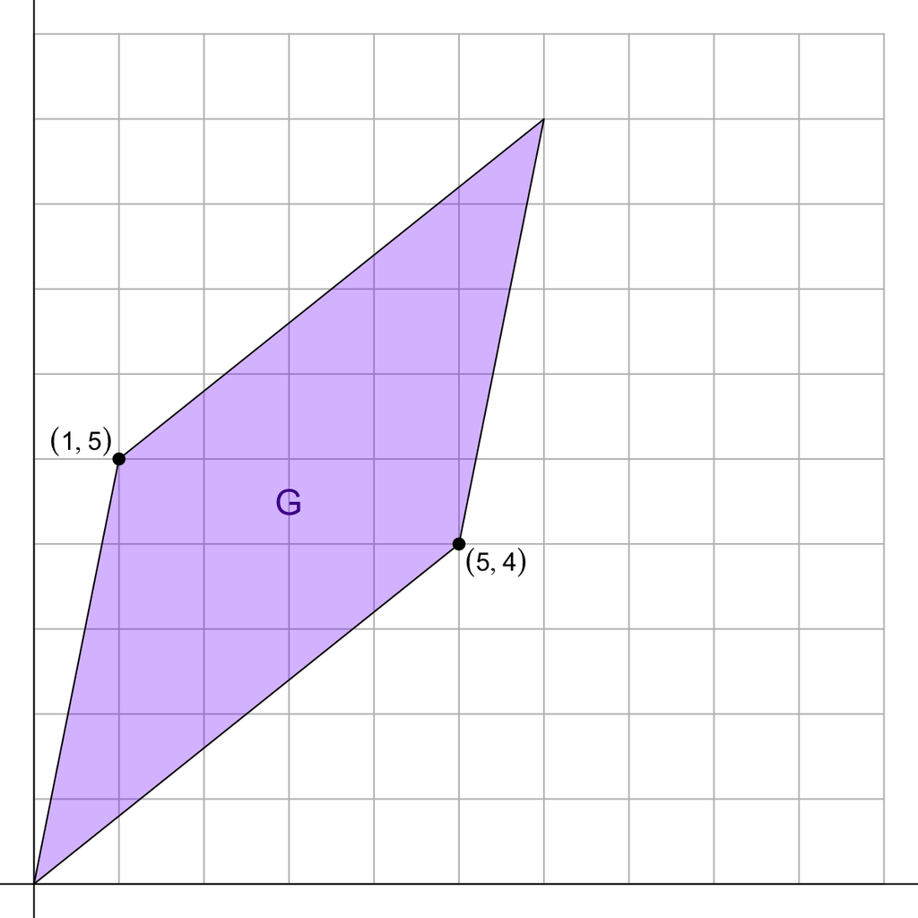

- $x_1 = 5$
- $y_1 = 4$
- $x_2 = 1$
- $y_2 = 5$

Use the formula.

$$G=|5\cdot5-1\cdot4|$$
$$G=21$$

There is actually a shortcut to finding the area of a parallelogram like the one shown below.

$$A=|x_1y_2-x_2y_1|$$

With that in mind, find the area of the parallelogram shown below, where each small grey square has an area of 1.

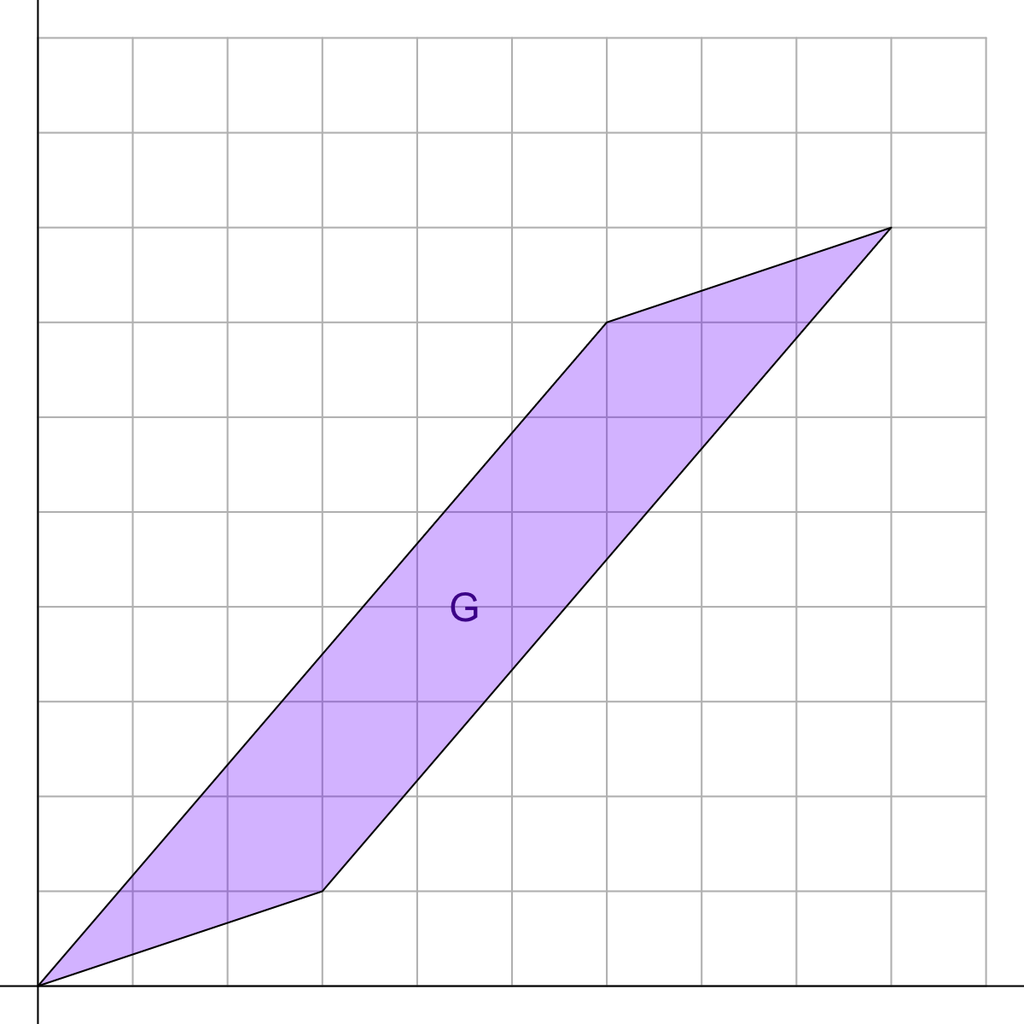

$$G=~?$$

Identify the coordinates of the vertices.

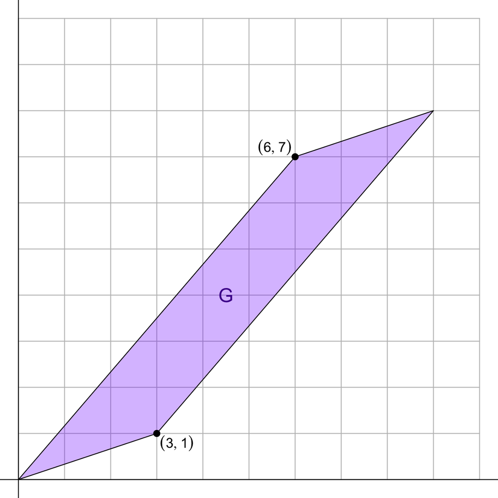

- $x_1 = 3$
- $y_1 = 1$
- $x_2 = 6$
- $y_2 = 7$

Use the formula.

$$G=|3\cdot7-6\cdot1|$$
$$G=15$$

There is actually a shortcut to finding the area of a parallelogram like the one shown below.

$$A=|x_1y_2-x_2y_1|$$

With that in mind, find the area of the parallelogram shown below, where each small grey square has an area of 1.

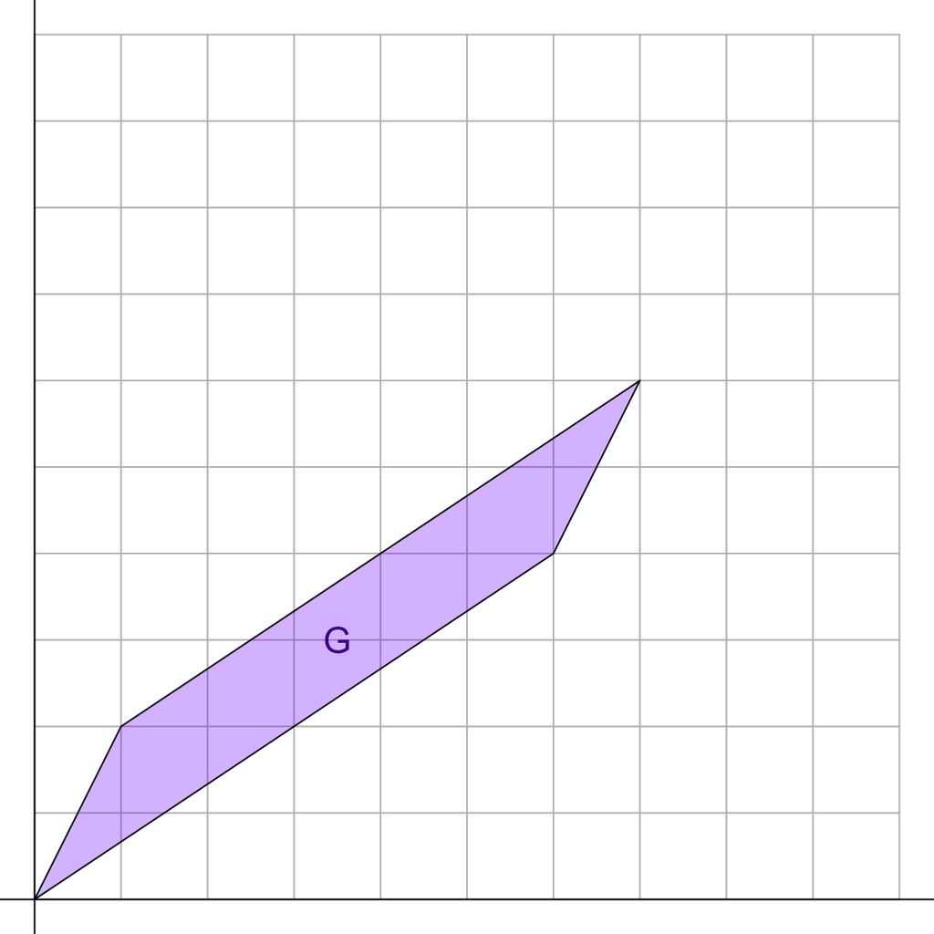

$$G=~?$$

Identify the coordinates of the vertices.

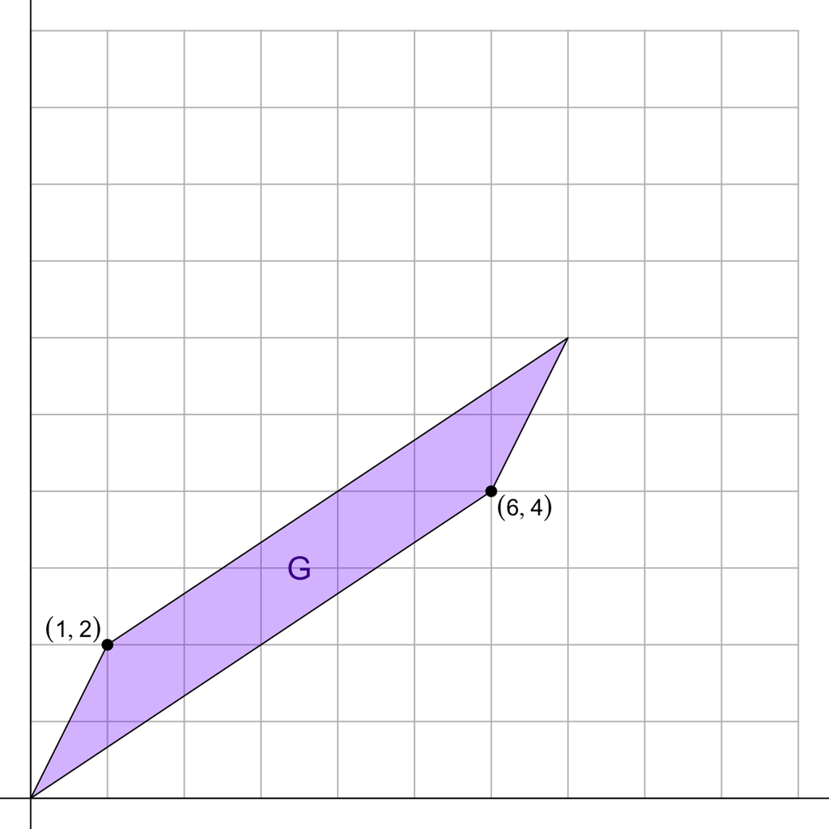

- $x_1 = 6$
- $y_1 = 4$
- $x_2 = 1$
- $y_2 = 2$

Use the formula.

$$G=|6\cdot2-1\cdot4|$$
$$G=8$$

There is actually a shortcut to finding the area of a parallelogram like the one shown below.

$$A=|x_1y_2-x_2y_1|$$

With that in mind, find the area of the parallelogram shown below, where each small grey square has an area of 1.

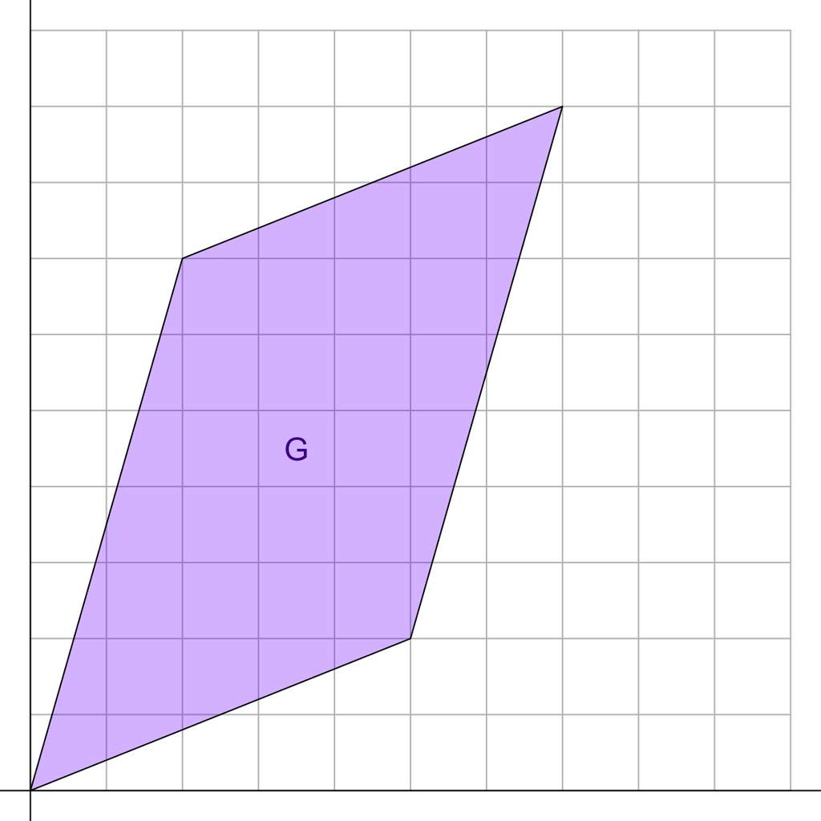

$$G=~?$$

Identify the coordinates of the vertices.

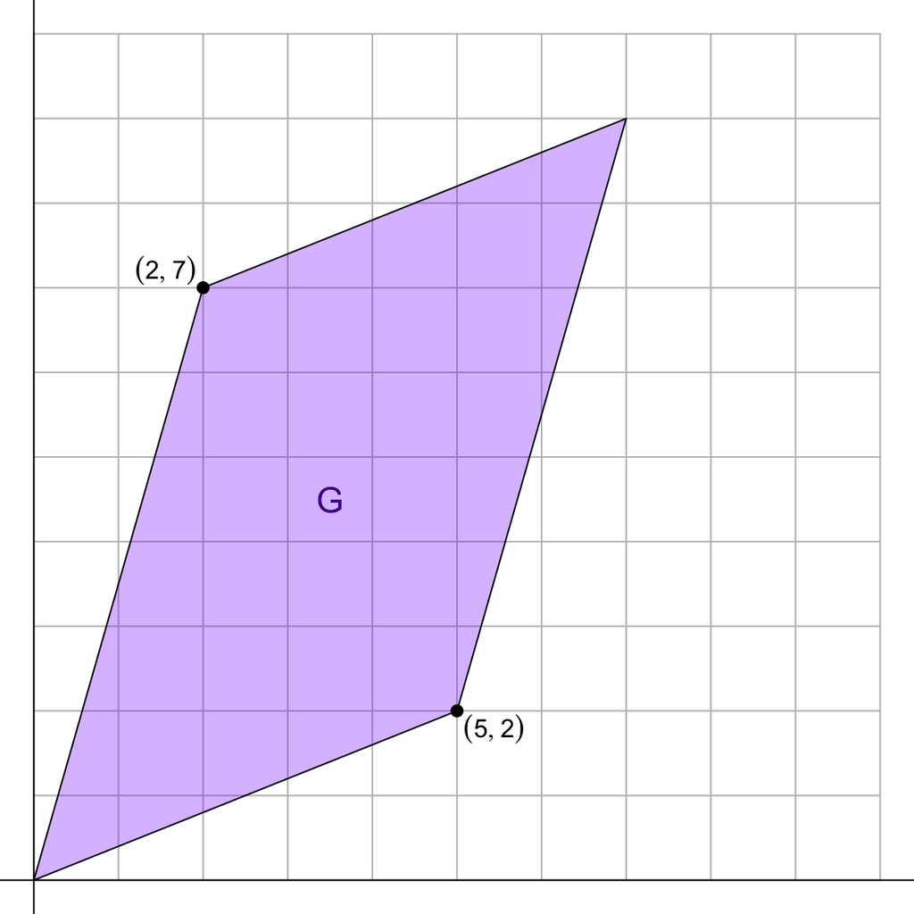

- $x_1 = 5$
- $y_1 = 2$
- $x_2 = 2$
- $y_2 = 7$

Use the formula.

$$G=|5\cdot7-2\cdot2|$$
$$G=31$$

There is actually a shortcut to finding the area of a parallelogram like the one shown below.

$$A=|x_1y_2-x_2y_1|$$

With that in mind, find the area of the parallelogram shown below, where each small grey square has an area of 1.

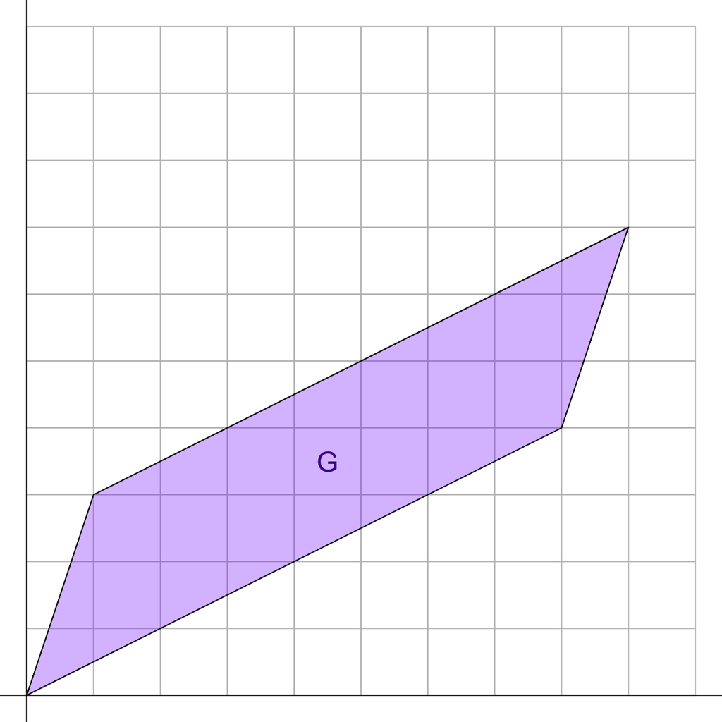

$$G=~?$$

Identify the coordinates of the vertices.

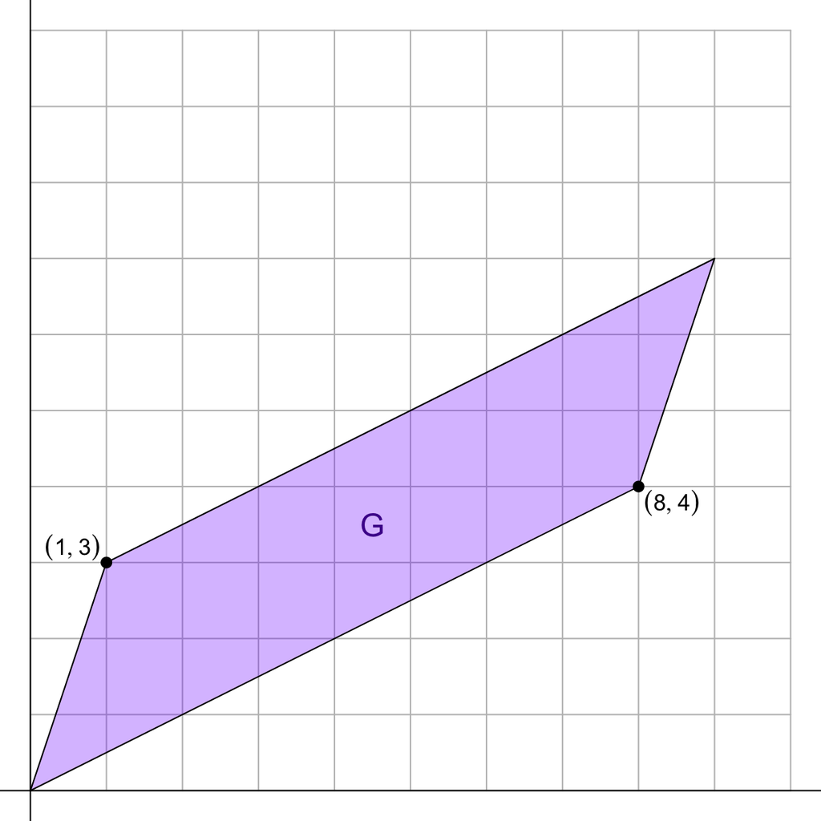

- $x_1 = 8$
- $y_1 = 4$
- $x_2 = 1$
- $y_2 = 3$

Use the formula.

$$G=|8\cdot3-1\cdot4|$$
$$G=20$$

There is actually a shortcut to finding the area of a parallelogram like the one shown below.

$$A=|x_1y_2-x_2y_1|$$

With that in mind, find the area of the parallelogram shown below, where each small grey square has an area of 1.

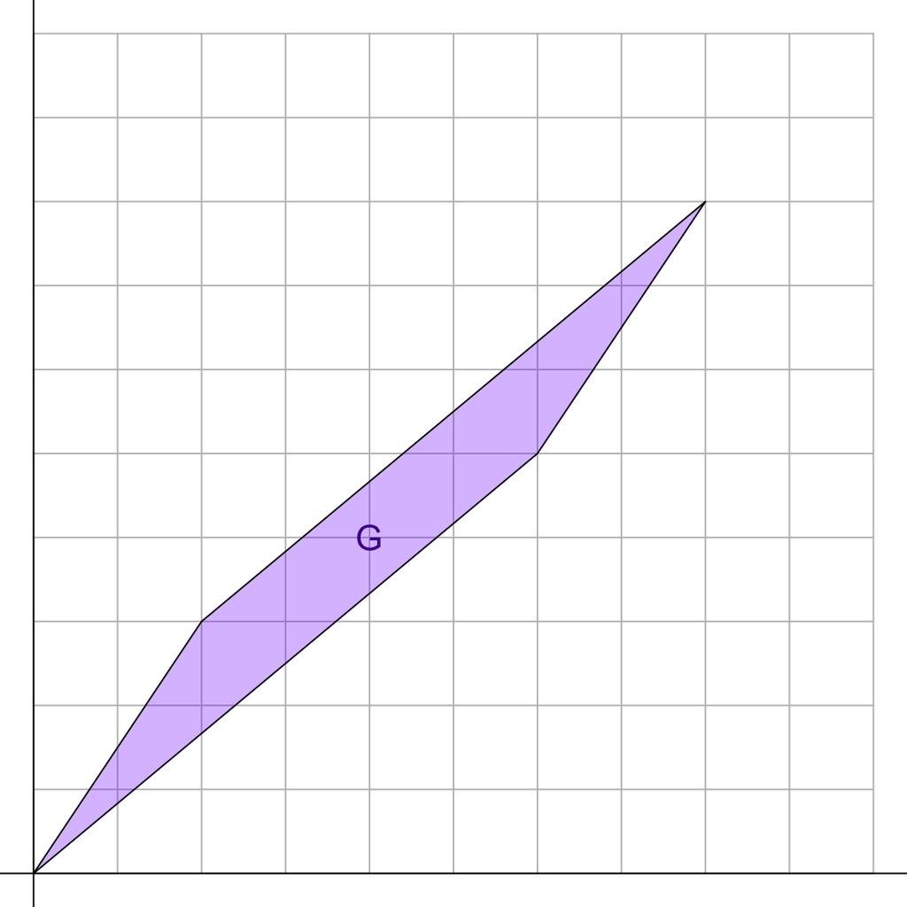

$$G=~?$$

Identify the coordinates of the vertices.

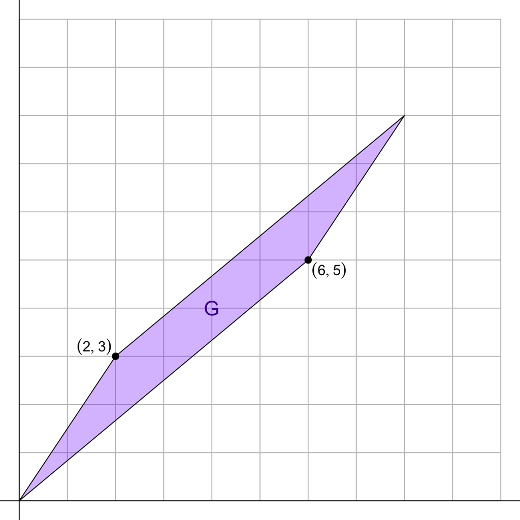

- $x_1 = 6$
- $y_1 = 5$
- $x_2 = 2$
- $y_2 = 3$

Use the formula.

$$G=|6\cdot3-2\cdot5|$$
$$G=8$$

There is actually a shortcut to finding the area of a parallelogram like the one shown below.

$$A=|x_1y_2-x_2y_1|$$

With that in mind, find the area of the parallelogram shown below, where each small grey square has an area of 1.

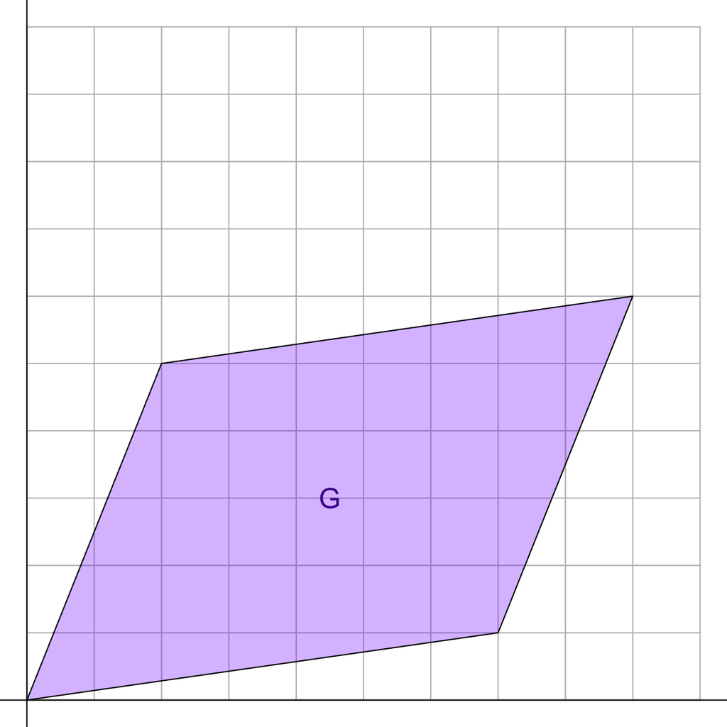

$$G=~?$$

Identify the coordinates of the vertices.

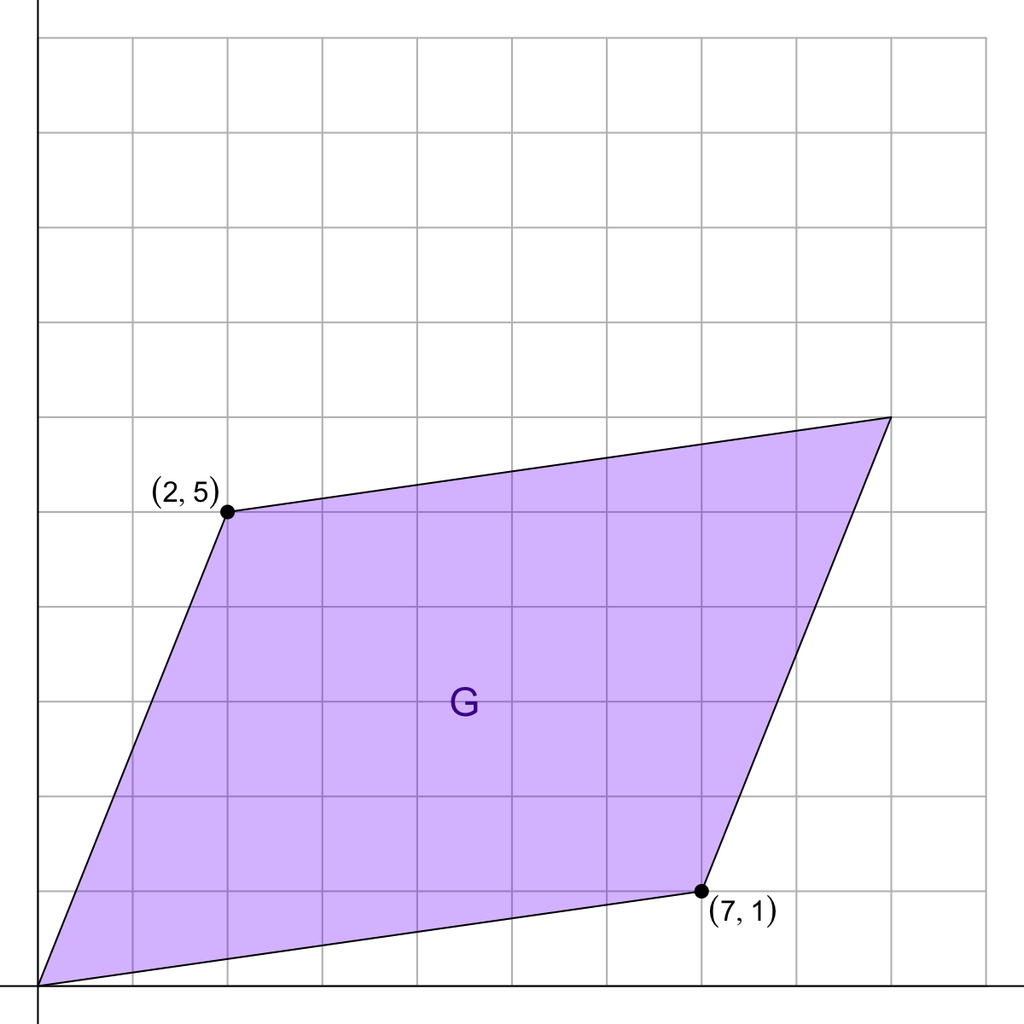

- $x_1 = 7$
- $y_1 = 1$
- $x_2 = 2$
- $y_2 = 5$

Use the formula.

$$G=|7\cdot5-2\cdot1|$$
$$G=33$$

There is actually a shortcut to finding the area of a parallelogram like the one shown below.

$$A=|x_1y_2-x_2y_1|$$

With that in mind, find the area of the parallelogram shown below, where each small grey square has an area of 1.

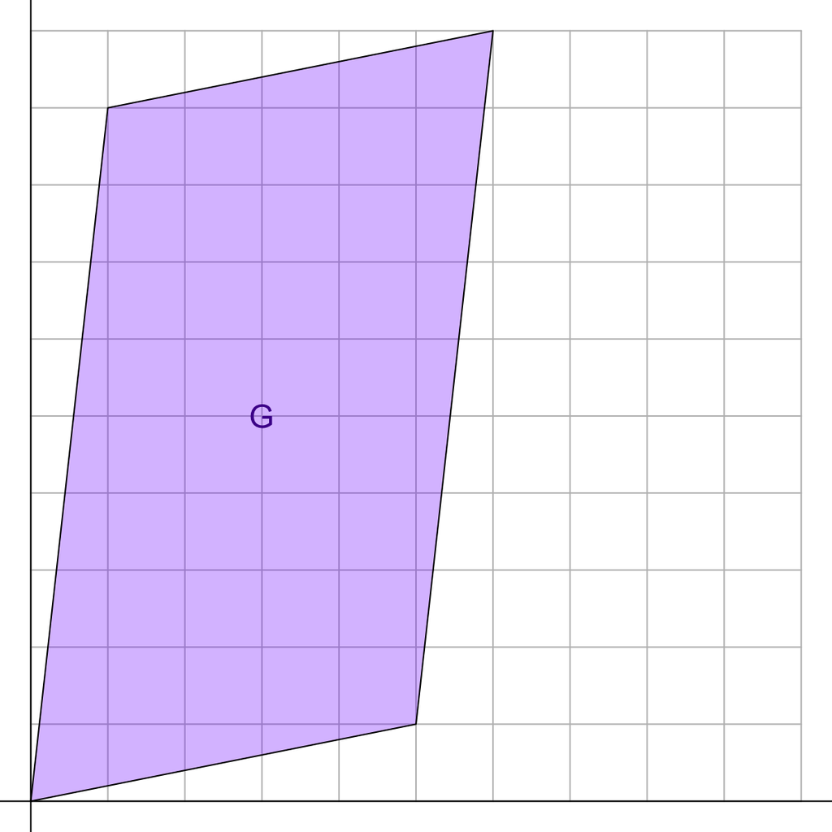

$$G=~?$$

Identify the coordinates of the vertices.

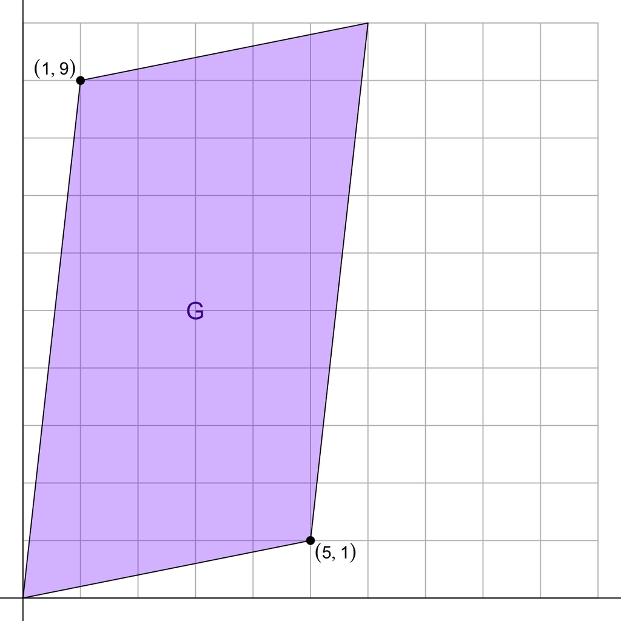

- $x_1 = 5$
- $y_1 = 1$
- $x_2 = 1$
- $y_2 = 9$

Use the formula.

$$G=|5\cdot9-1\cdot1|$$
$$G=44$$

There is actually a shortcut to finding the area of a parallelogram like the one shown below.

$$A=|x_1y_2-x_2y_1|$$

With that in mind, find the area of the parallelogram shown below, where each small grey square has an area of 1.

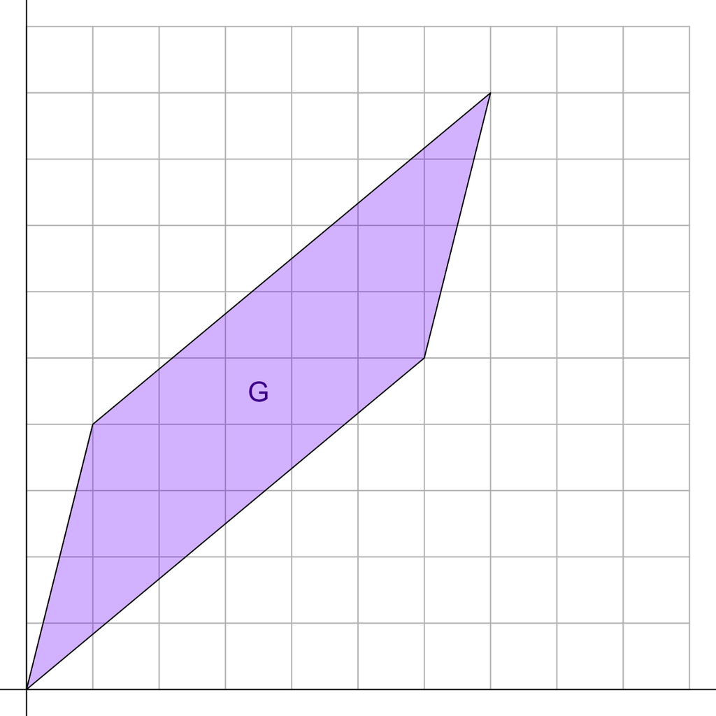

$$G=~?$$

Identify the coordinates of the vertices.

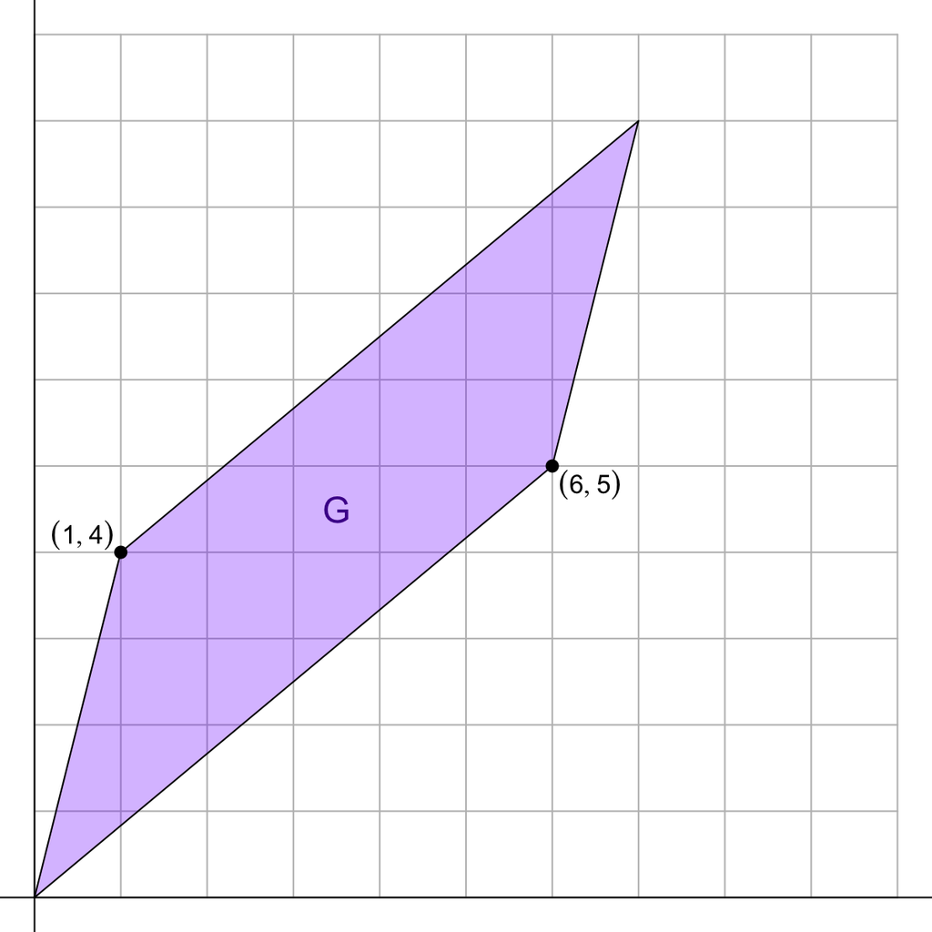

- $x_1 = 6$
- $y_1 = 5$
- $x_2 = 1$
- $y_2 = 4$

Use the formula.

$$G=|6\cdot4-1\cdot5|$$
$$G=19$$

There is actually a shortcut to finding the area of a parallelogram like the one shown below.

$$A=|x_1y_2-x_2y_1|$$

With that in mind, find the area of the parallelogram shown below, where each small grey square has an area of 1.

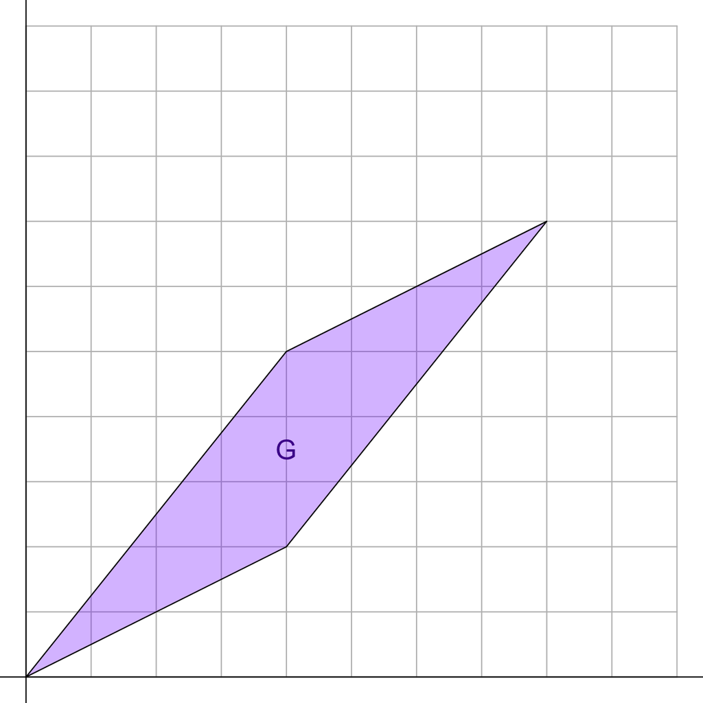

$$G=~?$$

Identify the coordinates of the vertices.

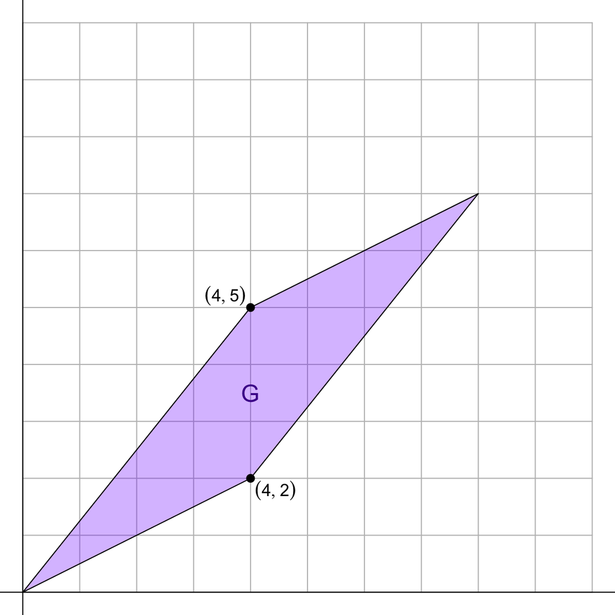

- $x_1 = 4$
- $y_1 = 2$
- $x_2 = 4$
- $y_2 = 5$

Use the formula.

$$G=|4\cdot5-4\cdot2|$$
$$G=12$$

There is actually a shortcut to finding the area of a parallelogram like the one shown below.

$$A=|x_1y_2-x_2y_1|$$

With that in mind, find the area of the parallelogram shown below, where each small grey square has an area of 1.

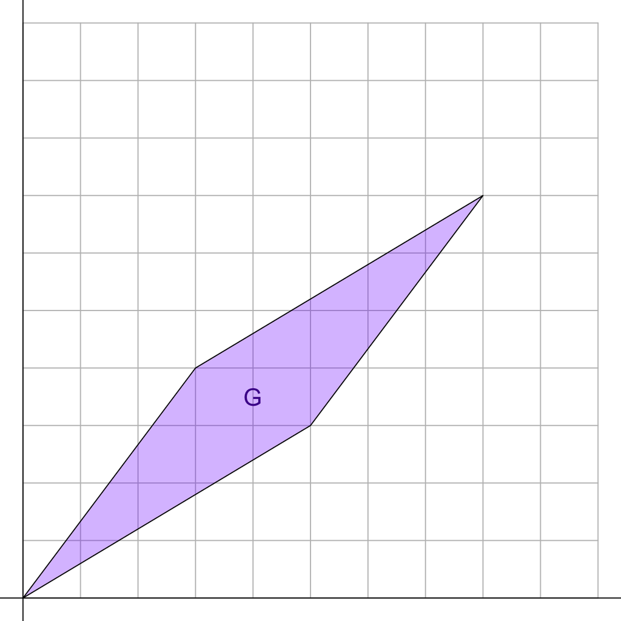

$$G=~?$$

Identify the coordinates of the vertices.

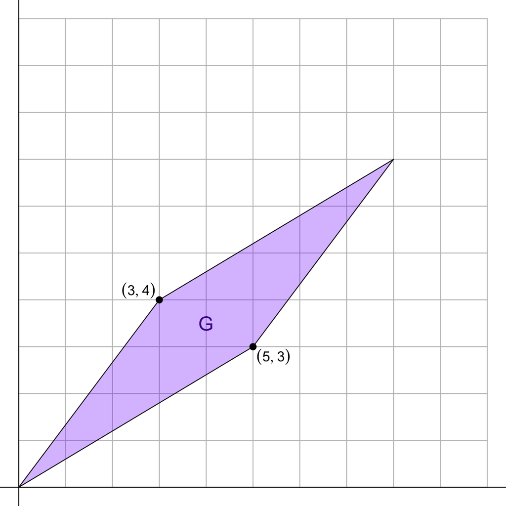

- $x_1 = 5$
- $y_1 = 3$
- $x_2 = 3$
- $y_2 = 4$

Use the formula.

$$G=|5\cdot4-3\cdot3|$$
$$G=11$$

There is actually a shortcut to finding the area of a parallelogram like the one shown below.

$$A=|x_1y_2-x_2y_1|$$

With that in mind, find the area of the parallelogram shown below, where each small grey square has an area of 1.

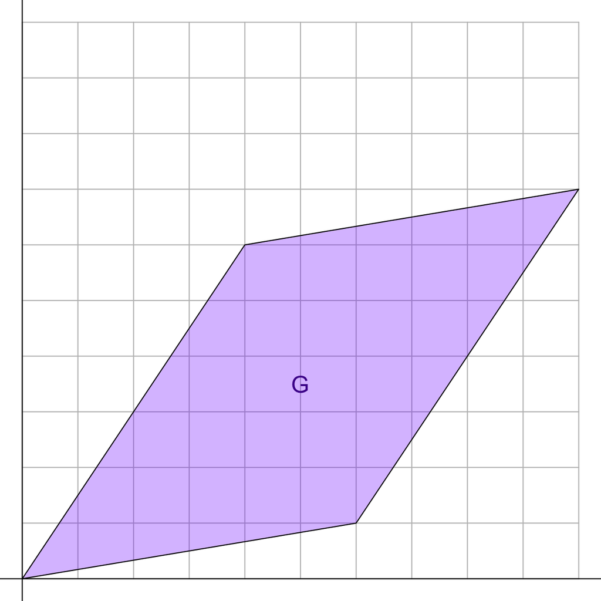

$$G=~?$$

Identify the coordinates of the vertices.

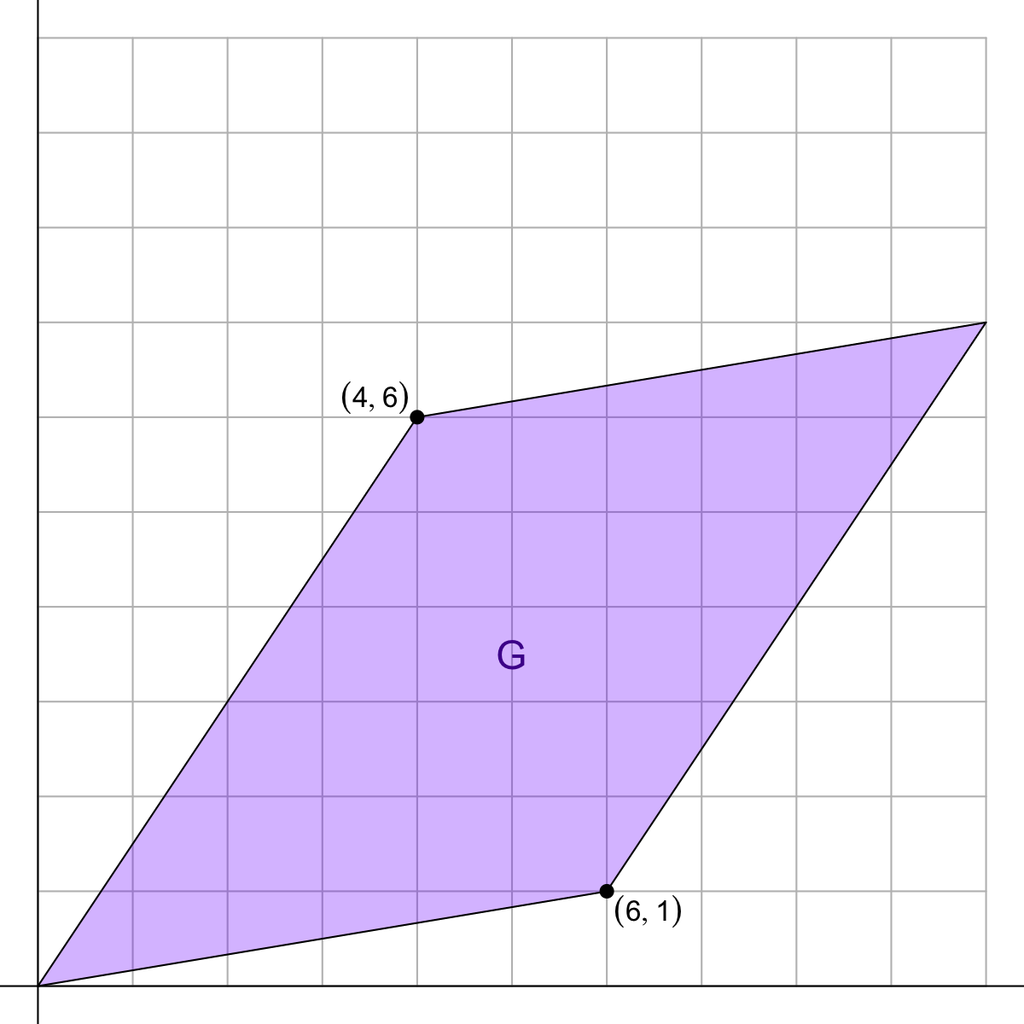

- $x_1 = 6$
- $y_1 = 1$
- $x_2 = 4$
- $y_2 = 6$

Use the formula.

$$G=|6\cdot6-4\cdot1|$$
$$G=32$$

There is actually a shortcut to finding the area of a parallelogram like the one shown below.

$$A=|x_1y_2-x_2y_1|$$

With that in mind, find the area of the parallelogram shown below, where each small grey square has an area of 1.

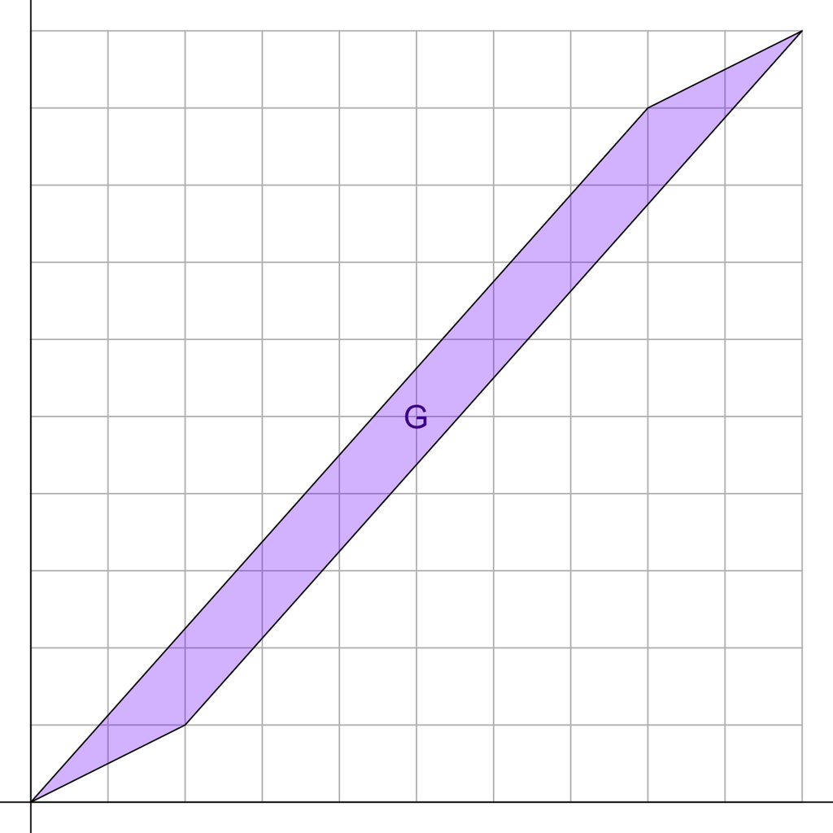

$$G=~?$$

Identify the coordinates of the vertices.

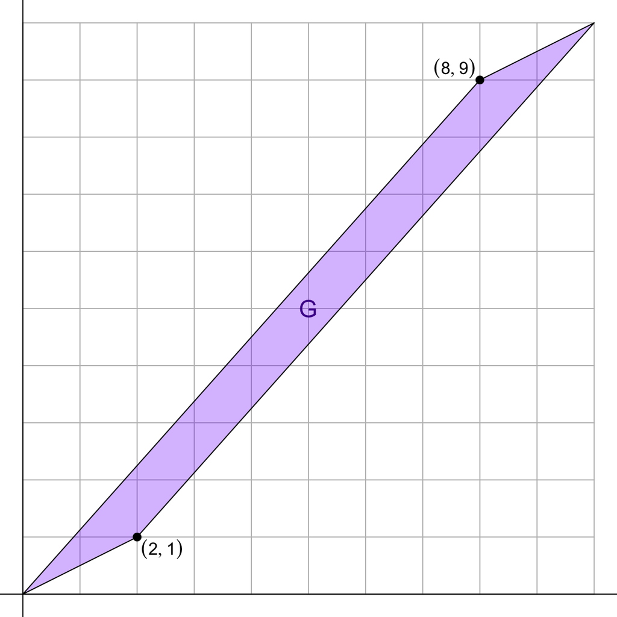

- $x_1 = 2$
- $y_1 = 1$
- $x_2 = 8$
- $y_2 = 9$

Use the formula.

$$G=|2\cdot9-8\cdot1|$$
$$G=10$$

There is actually a shortcut to finding the area of a parallelogram like the one shown below.

$$A=|x_1y_2-x_2y_1|$$

With that in mind, find the area of the parallelogram shown below, where each small grey square has an area of 1.

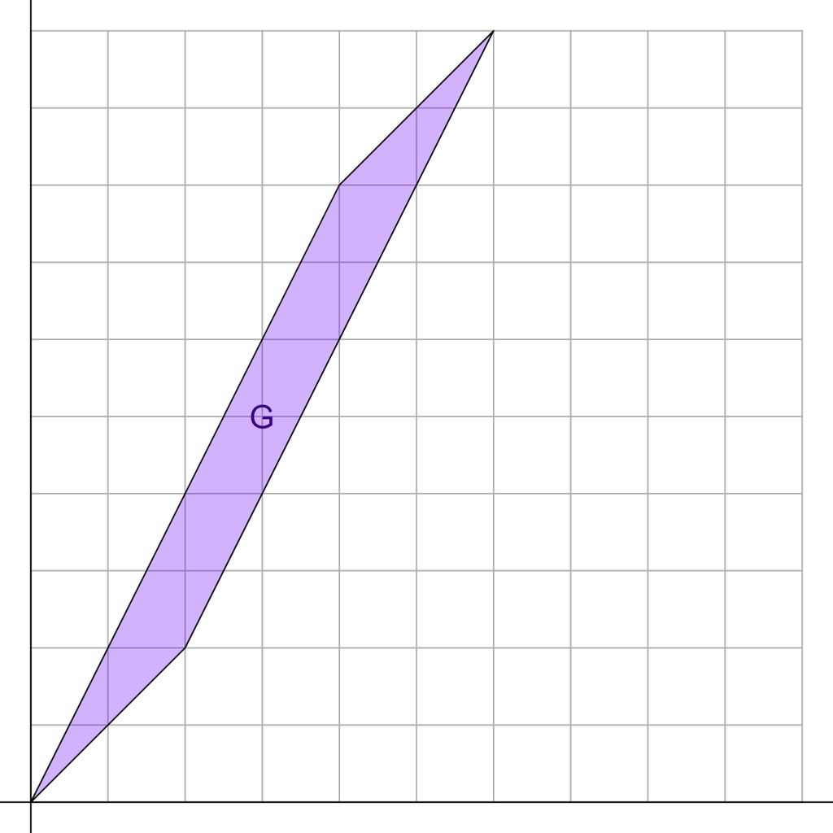

$$G=~?$$

Identify the coordinates of the vertices.

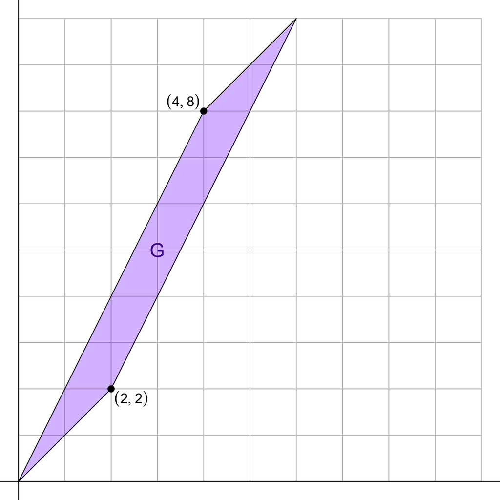

- $x_1 = 2$
- $y_1 = 2$
- $x_2 = 4$
- $y_2 = 8$

Use the formula.

$$G=|2\cdot8-4\cdot2|$$
$$G=8$$

There is actually a shortcut to finding the area of a parallelogram like the one shown below.

$$A=|x_1y_2-x_2y_1|$$

With that in mind, find the area of the parallelogram shown below, where each small grey square has an area of 1.

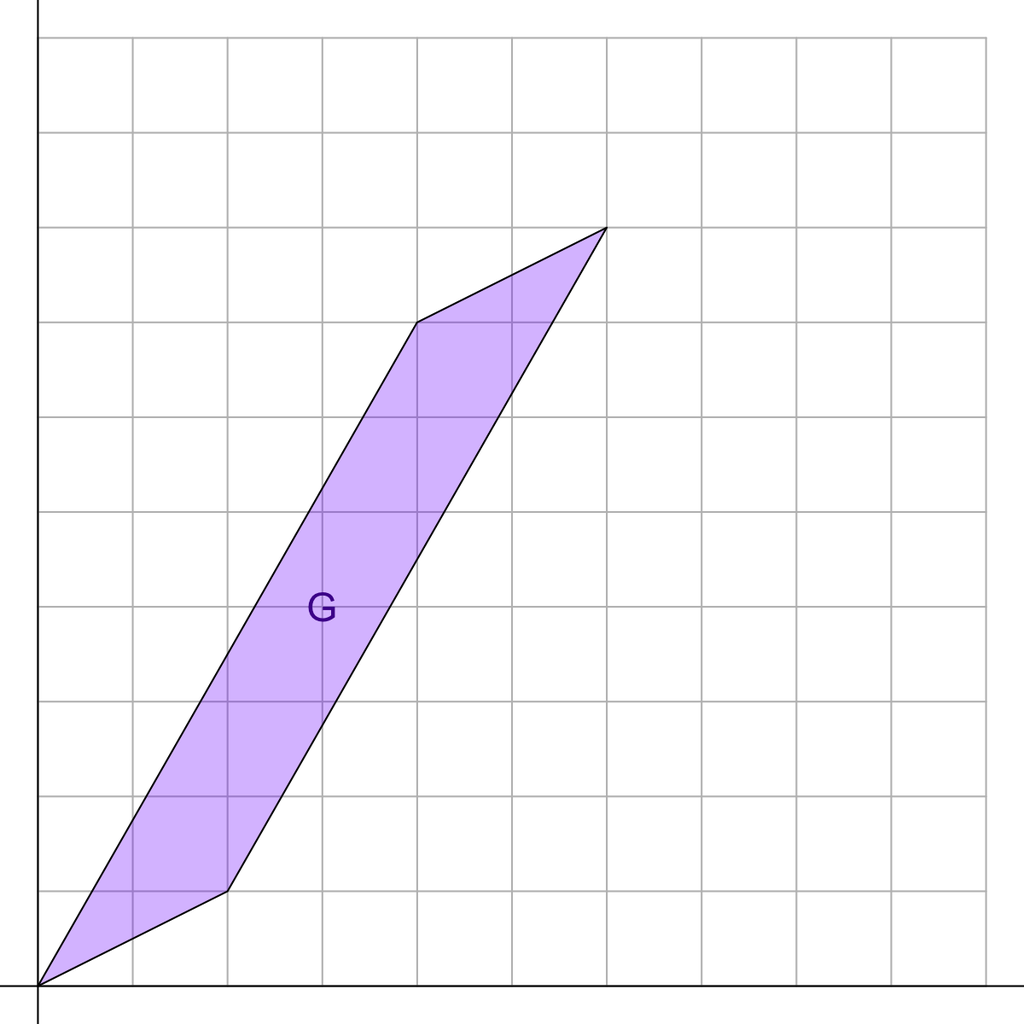

$$G=~?$$

Identify the coordinates of the vertices.

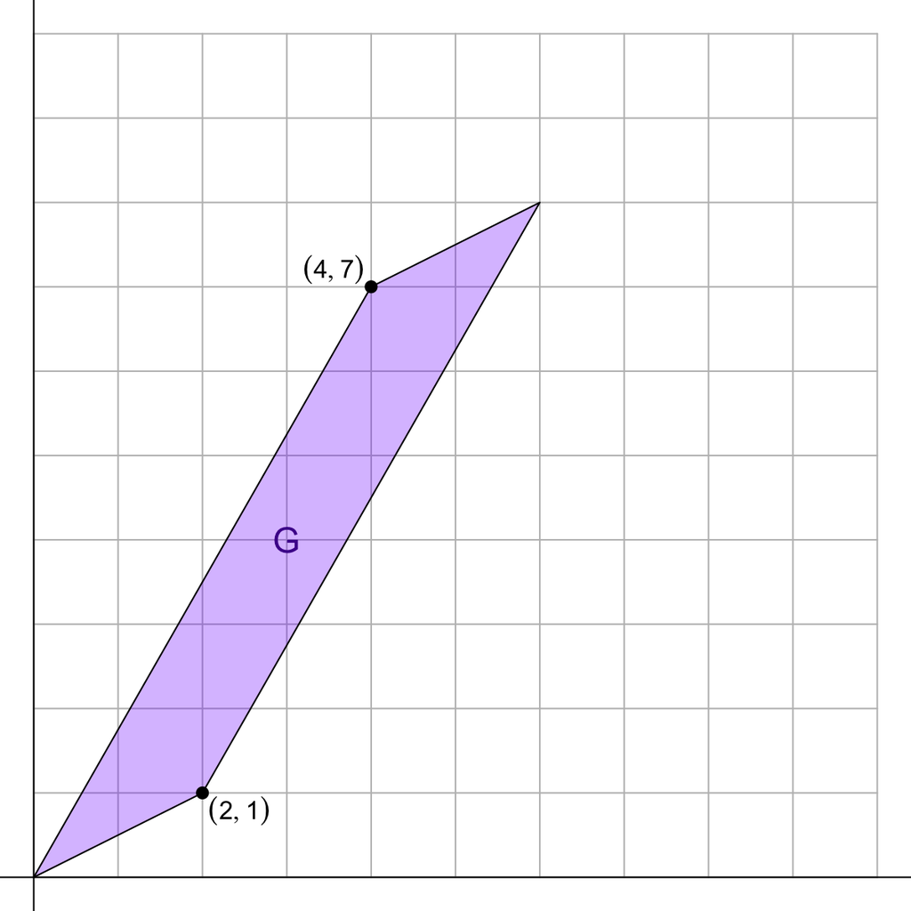

- $x_1 = 2$
- $y_1 = 1$
- $x_2 = 4$
- $y_2 = 7$

Use the formula.

$$G=|2\cdot7-4\cdot1|$$
$$G=10$$

There is actually a shortcut to finding the area of a parallelogram like the one shown below.

$$A=|x_1y_2-x_2y_1|$$

With that in mind, find the area of the parallelogram shown below, where each small grey square has an area of 1.

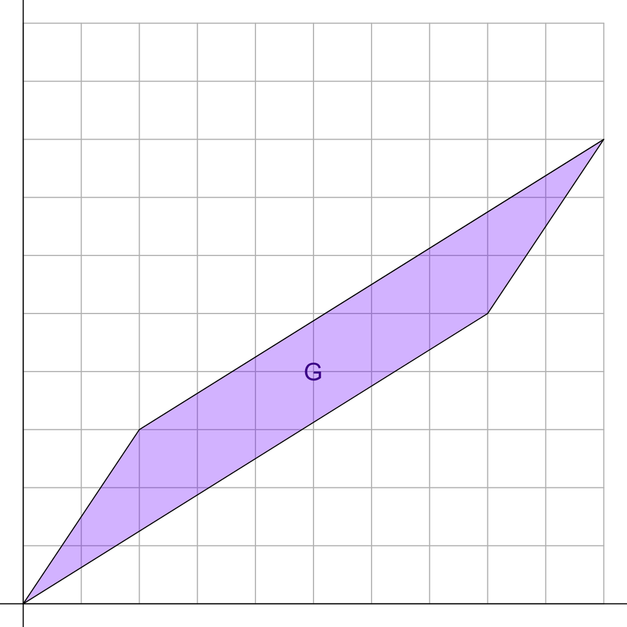

$$G=~?$$